```python
from IPython.display import Image
%matplotlib inline
```

# Decision Tree Learning

## Ý Tưởng:

Khi mỗi sáng cuối tuần thức dậy, chúng ta luôn đặt câu hỏi hôm nay làm việc hay đi chơi. Vì vậy muốn biết được kết quả thì cần đưa ra quyết định và quyết định này phụ thuộc vào các câu trả lời ứng với 1 loạt các câu hỏi liên quan:

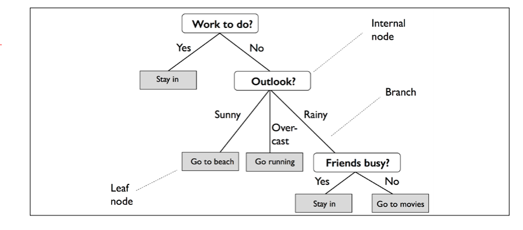

```python
Image(filename='vd_DT.png')
```

Decision Tree là một mô hình supervised learning, có thể được áp dụng vào cả hai bài toán classification và regression. Xây dựng decision tree trên tập training dataset là việc đi xác định các câu hỏi và thứ tự của chúng. Một điểm đáng lưu ý của thuật toán này là nó có thể làm việc với các đặc trưng ở dạng categorical, thường rời rạc và không có thứ tự, tuy nhiên decision tree vẫn làm việc với dữ liệu liên tục.

Đối với các bài toán có nhiều thuộc tính(feature) và mỗi thuộc tính lại có các giá trị khác nhau, việc cần làm là tại mỗi bước tính toán được thuộc tính tốt nhất, với mỗi thuộc tính được chọn sẽ chia dữ liệu vào các child node tương ứng với giá trị của thuộc tính và tiếp tục áp dụng tại mỗi child node. Sau mỗi lần phân chia dữ liệu sẽ cho được một kết quả là infomation Gain (IG)

Để đánh giá được chất lượng của các phân chia, cần đi tìm phép đo độ vẩn đục (impurity) hoặc độ tinh khiết (purity) của một phép phân chia. Decision Tree có hai loại: binary và multi.

## Infomation Gain (IG):

Để phân chia các node ứng với các thuộc tính, cần định nghĩa một objective function mà muốn tối ưu hóa. Objective function ở đây là tối đa hóa IG ở mỗi lần phân chia, được xác định như sau:

Decision Tree có nhiều nhánh tại một node:

$$IG(D_p, f) = I(D_p) - \sum_{j=1}^m \frac{N_j}{N_p} I(D_j)$$

Trong đó:

- $f$ là thuộc tính cần thực hiện phân chia
- $D_p$ và $D_j$ là tập dữ liệu của node cha và node con thứ j
- $I$ là mức đô độ vẩn đục của dữ liệu
- $N_p$ là tổng số giá trị training tại node cha
- $N_j$ là giá trị training tại node thứ j

Binary Decision Tree:

$$IG(D_p, f) = I(D_p) - \frac{N_{left}}{N_p} I(D_{left}) - \frac{N_{right}}{N_p} I(D_{right})$$

Có thể thấy IG là sự khác nhau giữa độ vẩn đục cha và tổng của độ vẩn đục con, nếu độ vẩn đục con càng nhỏ thì IG sẽ càng lớn

Có 3 loại thuật toán tính độ vẩn đục cho decision tree đó là: **Entropy , Gini impurity , classification error**

## Thuật toán Entropy (ID3):

### Hàm số entropy:

Cho một phân phối xác xuất của một biến rời rạc $x$ có thể nhận n giá trị khác nhau $x_1, x_2,...,x_n$. Giả sử xác xuất để $x$ nhận các giá trị này là $p_i = p(x = x_i)$ với $0 \leq p_i \leq 1, \sum_{i=1}^n p_i = 1$. Entropy của phân phôi này được định nghĩa là:

$$H(\mathbf{p}) = -\sum_{i=1}^n p_i \log_2(p_i)\quad\quad (1)$$

Ví dụ:

- với n=2, $p$ là **tinh khiết** nhất tức là một trong hai giá trị $p_i$ bằng 1, giá trị kia bằng 0 nên entropy của phân phối này là $H(p) = 0$
- Khi $p$ là **vẩn đục** nhất, tức là cả hai giá trị $p_i = 0.5$, khi này entropy sẽ có giá trị cao nhất là $H(p) = 1$

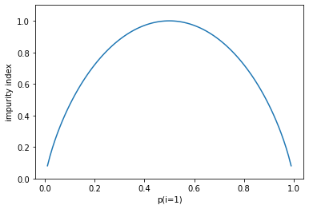

```python
import matplotlib.pyplot as plt
import numpy as np
def entropy(p):
    return - p*np.log2(p) - (1 - p)*np.log2((1 - p))

x = np.arange(0.0, 1.0, 0.01)
ent = [entropy(p) if p != 0 else None for p in x]
fig = plt.figure()
ax = plt.subplot(111)
line = ax.plot(x, ent, label='Entropy',
linestyle='-')
plt.ylim([0, 1.1])
plt.xlabel('p(i=1)')
plt.ylabel('impurity index')
```

Tổng quát: với n>2, hàm entropy đạt giá trị nhỏ nhất nếu có một giá trị $p_i = 1$, đạt giá trị lớn nhất nếu tất cả các $p_i$ bằng nhau.

### Thuật toán ID3:

Trong ID3, tổng có trọng số của entropy tại các leaf-node sau khi xây dựng được coi là hàm mất mát của decision tree. Công việc của ID3 là tìm các cách phân chia hợp lý sao cho hàm mất mát cuối cùng đạt giá trị càng nhỏ càng tốt.

Xét bài toán với $C$ class khác nhau, các điểm dữ liệu tạo thành một tập $S$ với số lượng phần từ là $|S|$ = $N$, giả sử trong $N$ điểm dữ liệu này có $N_c = 1, 2,..., C$ điểm thuộc class $c$. Xác xuất để mỗi điểm dữ liệu rơi vào class $c$ đó sấp xỉ bằng $\frac{N_c}{N}$. Vậy entropy tại node này được tính bởi:

$$H(\mathcal{S}) = -\sum_{c=1}^C \frac{N_c}{N} \log\left(\frac{N_c}{N}\right) \quad\quad(2)$$

Giả sử thuộc tính được chọn là $x$. Dựa trên $x$, các điểm dữ liệu trong $S$ được phân chia thành $K$ child node $S_1, S_2,..., S_K$ với số điểm trong mỗi child node lần lượt là $m_1, m_2,..., m_K$:

$$H(x, \mathcal{S}) = \sum_{k=1}^K \frac{m_k}{N} H(\mathcal{S}_k) \quad\quad (3)$$

là tổng có trọng số entropy của mỗi child node được tính tương tự như (2). Việc lấy trọng số này là quan trọng vì các node thường có số lượng điểm khác nhau.

Tiếp theo định nghĩa *infomation gain* dựa trên thuộc tính $x$:

$$G(x, \mathcal{S}) = H(\mathcal{S}) - H(x, \mathcal{S})$$

Trong ID3, tại mỗi node, thuộc tính được chọn được xác định dựa trên:

$$x^* = \arg\max_{x} G(x, \mathcal{S}) = \arg\min_{x} H(x, \mathcal{S})$$

#### Ví dụ:

Dưới đây là bảng dữ liệu mô tả mối quan hệ giữa thời tiết trong 14 ngày và việc đội bóng có thể chơi hay không.

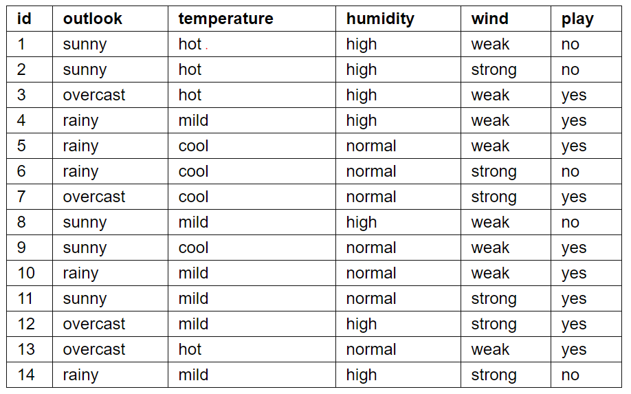

```python
Image(filename='vd_ID3_all.png')
```

Đây có thể được xem là một bài toán dự đoán đội bóng có chơi bóng được không dựa vào các thuộc tính thời tiết ở bảng trên.

Thứ tự các thuộc tính bằng thuật toán ID3.

Entropy tại root node:

$$H(\mathcal{S}) = - \frac{5}{14}\log\left(\frac{5}{14}\right) - \frac{9}{14}\log\left(\frac{9}{14}\right)\approx 0.65$$

Tiếp theo sẽ tính tổng có trọng số entropy của các child node của các thuộc tính *outlook, temperature, humidity, wind, play*.

Xét thuộc tính *outlook*, nhận 3 giá trị *sunny, over-cast, rainy*. Mỗi một giá trị sẽ tương ứng với một child node. Gọi tập hợp điểm trong mỗi child node lần lượt là $\mathcal{S}_s, \mathcal{S}_o, \mathcal{S}_r$ tương ứng với $m_s, m_o, m_r$ phần tử. Tiến hành sắp xếp lại bảng ban đầu theo thuộc tính *outlook* sẽ được các bảng nhỏ như sau:

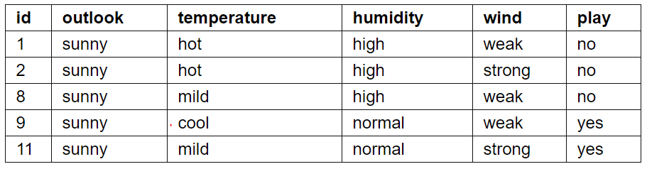

```python
Image(filename='vd_outlook_sunny.png')
```

Entropy của *outlook = sunny* sẽ bằng:

$$H(\mathcal{S}_s) = -\sum_{i=1}^{m_s} p_i \log(p_i) = -\frac{2}{5}\log\left(\frac{2}{5}\right) - \frac{3}{5}\log\left(\frac{3}{5}\right)\approx 0.673$$

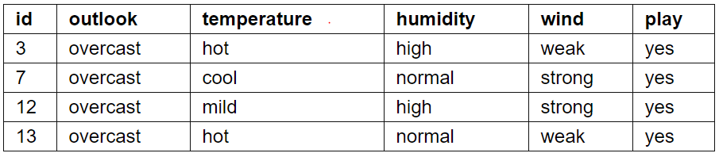

```python
Image(filename='vd_outlook_overcast.png')
```

Entropy của *outlook = over-cast* sẽ bằng:

$$H(\mathcal{S}_o) = -\sum_{i=1}^{m_o} p_i \log(p_i) = -\frac{4}{4}\log\left(\frac{4}{4}\right) = 0 $$

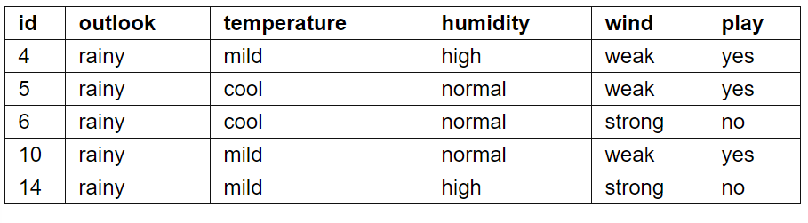

```python
Image(filename='vd_outlook_rainy.png')
```

Entropy của *outlook = rainy* sẽ bằng:

$$H(\mathcal{S}_r) = -\sum_{i=1}^{m_r} p_i \log(p_i) = -\frac{3}{5}\log\left(\frac{3}{5}\right) - \frac{2}{5}\log\left(\frac{2}{5}\right)\approx 0.673$$

Entropy của *outlook* sẽ bằng:

$$H(outlook, \mathcal{S}) = \frac{5}{14}H(\mathcal{S}_s) + \frac{4}{14}H(\mathcal{S}_o) + \frac{5}{14}H(\mathcal{S}_r)\approx 0.48$$

Tương tự như tính Entropy của *outlook*, các thuộc tính còn lại sẽ có giá trị như sau:

$$H(temperature, \mathcal{S}) \approx 0.631$$$$H(humidity, \mathcal{S}) \approx 0.547$$$$H(wind, \mathcal{S}) \approx 0.618$$

Như vậy, thuộc tính cần chọn ở root tree là *outlook* vì $H(outlook, \mathcal{S})$ đạt giá trị nhỏ nhất (IG là lớn nhất)

Sau bước xác định được root tree, sau đó sẽ nhận được ba child node với các phần tử như trong ba Bảng phân chia theo *outlook*. Child node có giá trị over-cast không cần phân chia tiếp vì nó đã được tinh khiết. Và hai thuộc tính còn lại vẫn còn vẩn đục cho nên cần được phân chia tiếp

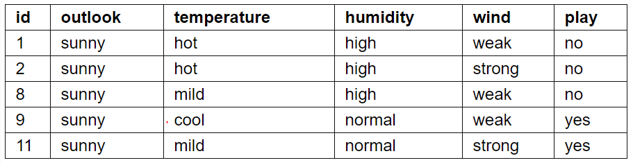

```python
Image(filename='vd_outlook_sunny.png')
```

Tiến hành, phân chia dữ liệu bên nhánh *outlook = sunny*:

$H(temperature, \mathcal{S_s}) \approx 0.268$

$H(humidity, \mathcal{S_s}) = 0$

$H(wind, \mathcal{S_s}) \approx 0.646$

Nên, trong nhánh *outlook = sunny* sẽ chọn thuộc tính humidity làm node tiếp theo.

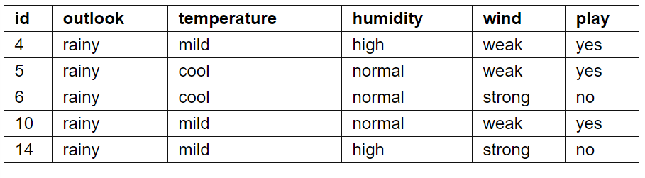

```python
Image(filename='vd_outlook_rainy.png')
```

Tiến hành, phân chia dữ liệu bên nhánh *outlook = rainy*:

$H(temperature, \mathcal{S_s}) \approx 0.646$

$H(wind, \mathcal{S_s}) \approx 0$

Nên, trong nhánh *outlook = rainy* sẽ chọn thuộc tính wind làm node tiếp theo.

Như vậy, Decision Tree cho bài toán trên dựa theo ID3 sẽ có dạng:

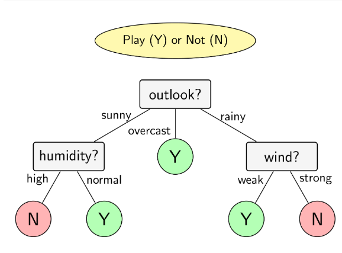

```python
Image(filename='vd_DT_foolball.png')
```

```python
from sklearn.tree import DecisionTreeClassifier
from sklearn import datasets
import numpy as np
from sklearn.model_selection import train_test_split
from sklearn.preprocessing import StandardScaler
iris = datasets.load_iris()
#2: petal length
#3: petal width
X = iris.data[:, [2, 3]]
y = iris.target

X_train, X_test, y_train, y_test = train_test_split(
    X, y, test_size=0.3, random_state=1, stratify=y)
```

```python
from matplotlib.colors import ListedColormap
import matplotlib.pyplot as plt


def plot_decision_regions(X, y, classifier, test_idx=None, resolution=0.02):

    # setup marker generator and color map
    markers = ('s', 'x', 'o', '^', 'v')
    colors = ('red', 'blue', 'lightgreen', 'gray', 'cyan')
    cmap = ListedColormap(colors[:len(np.unique(y))])

    # plot the decision surface
    x1_min, x1_max = X[:, 0].min() - 1, X[:, 0].max() + 1
    x2_min, x2_max = X[:, 1].min() - 1, X[:, 1].max() + 1
    xx1, xx2 = np.meshgrid(np.arange(x1_min, x1_max, resolution),
                           np.arange(x2_min, x2_max, resolution))
    Z = classifier.predict(np.array([xx1.ravel(), xx2.ravel()]).T)
    Z = Z.reshape(xx1.shape)
    plt.contourf(xx1, xx2, Z, alpha=0.3, cmap=cmap)
    plt.xlim(xx1.min(), xx1.max())
    plt.ylim(xx2.min(), xx2.max())

    for idx, cl in enumerate(np.unique(y)):
        plt.scatter(x=X[y == cl, 0],
                    y=X[y == cl, 1],
                    alpha=0.8,
                    c=colors[idx],
                    marker=markers[idx],
                    label=cl,
                    edgecolor='black')

    # highlight test examples
    if test_idx:
        # plot all examples
        X_test, y_test = X[test_idx, :], y[test_idx]

        plt.scatter(X_test[:, 0],
                    X_test[:, 1],
                    c='',
                    edgecolor='black',
                    alpha=1.0,
                    linewidth=1,
                    marker='o',
                    s=100,
                    label='test set')
```

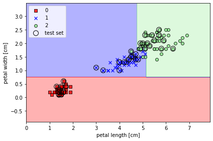

```python
from sklearn.tree import DecisionTreeClassifier
tree_model = DecisionTreeClassifier(criterion='entropy', max_depth=4, random_state=1)
tree_model.fit(X_train, y_train)
X_combined = np.vstack((X_train, X_test))
y_combined = np.hstack((y_train, y_test))
plot_decision_regions(X_combined, y_combined, classifier=tree_model, test_idx=range(105, 150))
plt.xlabel('petal length [cm]')
plt.ylabel('petal width [cm]')
plt.legend(loc='upper left')
plt.tight_layout()
plt.show()
```

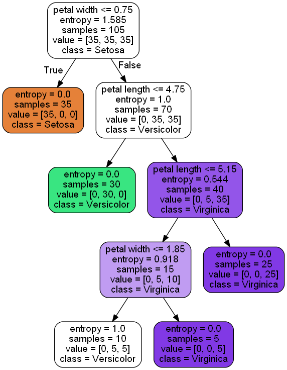

```python
from sklearn.externals.six import StringIO
from IPython.display import Image
from sklearn.tree import export_graphviz
from pydotplus import graph_from_dot_data
import pydotplus
import graphviz
import os

os.environ["PATH"] += os.pathsep + 'C:\\Program Files (x86)\\Graphviz2.38\\bin'
dot_data = StringIO()
dot_data = export_graphviz(tree_model, filled=True, rounded=True, class_names=['Setosa', 'Versicolor', 'Virginica'],
                            feature_names=['petal length', 'petal width'], out_file=None)
graph = graph_from_dot_data(dot_data)
Image(graph.create_png())
```

## Gini Index:

Là phương pháp hướng đến đo lường tần suất một đối tượng dữ liệu ngẫu nhiên trong tập dữ liệu ban đầu được phân loại không chính xác, trên cơ sở đối tượng dữ liệu đã nằm trong một tập con đã được phân ra từ tập dữ liệu ban đầu, có dán nhãn thể hiện thuộc tính chung bất kỳ của các đối tượng còn lại trong tập con này, giá trị phân loại chính là nhãn của tập con

Gini index chính là chỉ số đo lường mức độ đồng nhất hay nhiễu loạn của thông tin, hay sự khác biệt về các giá trị mà mỗi điểm dữ liệu trong một tập con, hoặc một nhánh của cây quyết định. Công thức Gini có thể dùng cho cả biến định tính và định lượng. Nếu điểm dữ liệu thuộc về một node và có chung thuộc tính bất kỳ thì node này thể hiện sự đồng nhất lúc này $gini = 0$ và ngược lại gini sẽ lớn, lớn nhất bằng 0.5.

Gini thường được dùng cho thuật toán CART(classification and regression Tree) giới hạn tree chỉ có tối đa 2 nhánh.

Công thức tổng quát của Gini:

$$G(p) = \sum_{i=1}^{n} p_i(1 - p_i) = 1 - \sum_{i=1}^{n} (p_i)^2$$

Công thức trên để tính độ đồng nhất của một node, khi có nhiều cách phân nhánh mỗi cách có thể phân ra một số node nhất định. Cho nên, lúc này có thêm công thức thứ 2 để tìm ra các phân chia tối ưu nhất:

$$G_{split} = \sum_{i=1}^{k} \frac{N_i}{N} G(i)$$

Trong đó:

- $N_i$ là số điểm dữ liệu có trong node của nhánh được phân
- $N$ là số điểm dữ liệu có trong node được dùng để phân nhánh

Hệ số $G_{split}$ càng nhỏ thì cách phân nhánh đó càng tối ưu.

#### Ví dụ:

Sử dụng dữ liệu của ví dụ bên ID3:

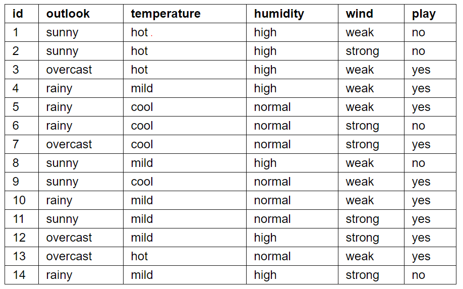

```python
Image(filename='vd_ID3_all.png')
```

Gini của thuộc tính *outlook = sunny*:

$G(sunny) = 1 - (\frac{2}{5})^2 - (\frac{3}{5})^2 = 0.48$

$G(over-cast) = 1 - (\frac{4}{4})^2 = 0$

$G(rainy) = 1 - (\frac{2}{5})^2 - (\frac{3}{5})^2 = 0.48$

Từ đó có được $Gini$ của thuộc tính *outlook* sẽ bằng:

$G_{split} = \frac{5}{14}G(sunny) + \frac{4}{14}G(over-cast) + \frac{5}{14}G(rainy) = \frac{5}{14}0.48 + \frac{4}{14}0 + \frac{5}{14}0.48 \approx 0.34$

Lần lượt, sẽ được giá trị $Gini$ của các thuộc tính còn lại:

$G_{split}(temperature) \approx 0.43$

$G_{split}(humidity) \approx 0.365$

$G_{split}(wind) \approx 0.43$

Như vậy, thấy rằng thuộc tính *outlook* sẽ có giá trị $Gini$ nhỏ nhất cho nên chọn làm root node. Sau khi chọn được root node, dữ liệu sẽ được rút gọn lại như sau:

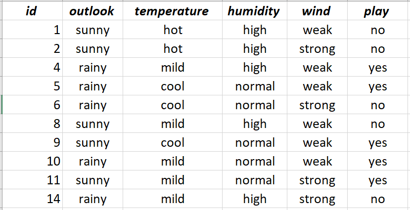

```python
Image(filename='vd_gini_outlook.png')
```

Tiếp tục phân chia theo các thuộc tính còn lại:

$G_{split}(temperature) \approx 0.468$

$G_{split}(humidity) \approx 0.32$

$G_{split}(wind) \approx 0.414$

Như vậy thuộc tính tiếp theo được chọn là child node là *humidity*, tương tự các bước sau vẫn được làm như vậy.

Kết quả của $Gini$ cho ví dụ trên sẽ cho ra một cây như sau:

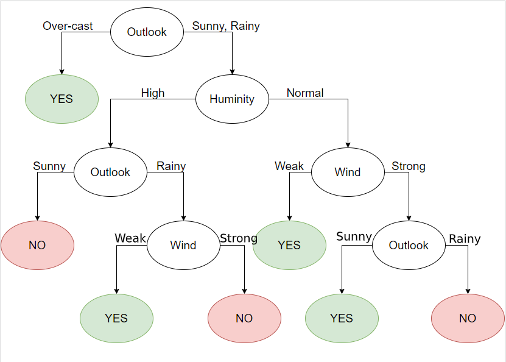

```python
Image(filename='vd_gini_tree.png')
```

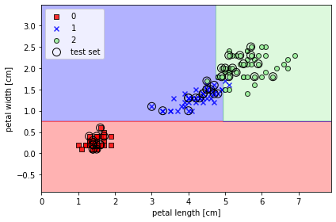

```python
from sklearn.tree import DecisionTreeClassifier
tree_model = DecisionTreeClassifier(criterion='gini', max_depth=4, random_state=1)
tree_model.fit(X_train, y_train)
X_combined = np.vstack((X_train, X_test))
y_combined = np.hstack((y_train, y_test))
plot_decision_regions(X_combined, y_combined, classifier=tree_model, test_idx=range(105, 150))
plt.xlabel('petal length [cm]')
plt.ylabel('petal width [cm]')
plt.legend(loc='upper left')
plt.tight_layout()
plt.show()
```

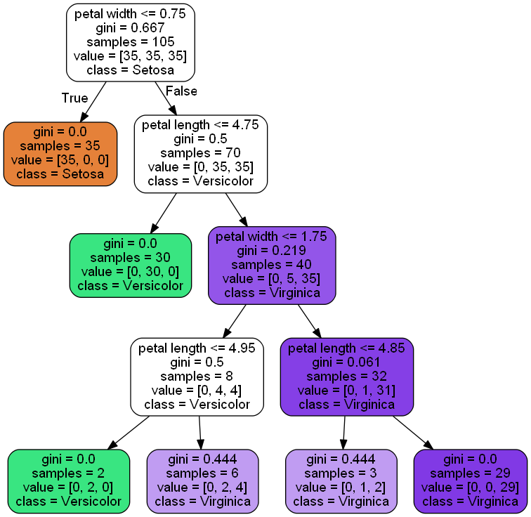

```python
from sklearn.externals.six import StringIO
from IPython.display import Image
from sklearn.tree import export_graphviz
from pydotplus import graph_from_dot_data
import pydotplus
import graphviz
import os

os.environ["PATH"] += os.pathsep + 'C:\\Program Files (x86)\\Graphviz2.38\\bin'
dot_data = StringIO()
dot_data = export_graphviz(tree_model, filled=True, rounded=True, class_names=['Setosa', 'Versicolor', 'Virginica'],
                            feature_names=['petal length', 'petal width'], out_file=None)
graph = graph_from_dot_data(dot_data)
Image(graph.create_png())
```

## Classification Error:

$$E(p) = 1 - max({p_i})$$

### Ví dụ:

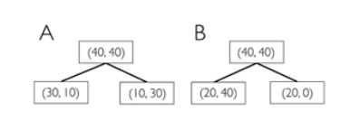

```python
Image(filename='class_error.png', width = 500)
```

Áp dụng *classification error*:

$$E(D_p) = 1 - 0.5 = 0.5$$$$A: E(D_{left}) = 1 - \frac{3}{4} = 0.25$$$$A: E(D_{right}) = 1 - \frac{3}{4} = 0.25$$$$A: IG_E = 0.5 - \frac{4}{8}0.25 - \frac{4}{8}0.25 = 0.25$$$$B: E(D_{left}) = 1 - \frac{4}{6} = \frac{1}{3}$$$$B: E(D_{right}) = 1 - 1 = 0$$$$B: IG_E = 0.5 - \frac{6}{8}\times\frac{1}{3} - 0 = 0.25$$

Áp dụng *gini*:

$$E(D_p) = 1 - 0.5 = 0.5$$$$A: G(D_{left}) = 1 - (\frac{3}{4})^2 - (\frac{1}{4})^2 = 0.375$$$$A: G(D_{right}) = 1 - (\frac{3}{4})^2 - (\frac{1}{4})^2 = 0.375$$$$A: IG_G = 0.5 - \frac{4}{8}0.375 - \frac{4}{8}0.375 = 0.125$$$$B: G(D_{left}) = 1 - (\frac{2}{6})^2 - (\frac{4}{6})^2 \approx 0.4$$$$B: G(D_{right}) = 1 - 1^2 - 0^2 = 0$$$$B: IG_G = 0.5 - \frac{6}{8}0.4 - 0 \approx 0.16$$

Tương tự với *entropy*:

$$A: IG_G = 0.19$$$$B: IG_G = 0.31$$

### Vualize so sánh sự khác nhau của ba cách đo độ vẩn đục

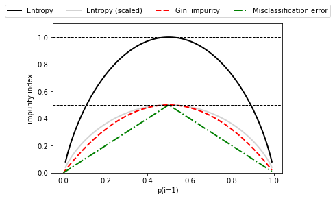

```python
import matplotlib.pyplot as plt
import numpy as np
def gini(p):
    return (p)*(1 - (p)) + (1 - p)*(1 - (1-p))
def entropy(p):
    return - p*np.log2(p) - (1 - p)*np.log2((1 - p))
def error(p):
    return 1 - np.max([p, 1 - p])
x = np.arange(0.0, 1.0, 0.01)
ent = [entropy(p) if p != 0 else None for p in x]
sc_ent = [e*0.5 if e else None for e in ent]
err = [error(i) for i in x]
fig = plt.figure()
ax = plt.subplot(111)
for i, lab, ls, c, in zip([ent, sc_ent, gini(x), err],
                          ['Entropy', 'Entropy (scaled)','Gini impurity', 'Misclassification error'],
                          ['-', '-', '--', '-.'],
                          ['black', 'lightgray', 'red', 'green', 'cyan']):
    line = ax.plot(x, i, label=lab, linestyle=ls, lw=2, color=c)
ax.legend(loc='upper center', bbox_to_anchor=(0.5, 1.15), ncol=5, fancybox=True, shadow=False)
ax.axhline(y=0.5, linewidth=1, color='k', linestyle='--')
ax.axhline(y=1.0, linewidth=1, color='k', linestyle='--')
plt.ylim([0, 1.1])
plt.xlabel('p(i=1)')
plt.ylabel('impurity index')
```

## Điều kiện dừng:

Trong các thuật toán của decision tree, nếu tiếp tục phân chia các node chưa tình khiết. sẽ thu được một tree tại mọi điểm trong training dataset đều được dự đoán đúng, lúc này tree sẽ rất sâu và phức tạp, có khả năng dẫn đến overfitting xảy ra.

Để tránh overfitting xảy ra, có một số phương pháp có thể được sử dụng. Tại một node, nếu có trong các điều kiện sau xảy ra, thì sẽ không tiếp tục phân chia node đó nữa:

- Nếu node có impurity = 0, tức lại mọi điểm đều thuộc một class.
- Nêu node có só phần từ nhỏ hơn một ngưỡng nào đó. Trong trường hợp này sẽ chấp nhận việc có một số điểm bị phân lớp sai
- Nếu chiều sâu của tree đạt đến một giới hạn nào đó.
- Nếu tổng số leaf node vượt quá một ngưỡng nào đó.
- Nếu việc phân chia node không làm giảm Impurity quá nhiều.

Ngoài các phương pháp trên, một phương pháp phổ biến khác được sử dụng để tránh overfitting là *pruning* (cắt tỉa).

## Random forests dựa vào sự kết hợp của nhiều decision tree

Sự xuất hiện của decision tree là tiền đề rất quan trọng cho việc ra ddwoif của rất nhiều thuật toán Machine Learning đang được sử dụng hiện nay như: *Random forest, Gradient Boosting, XGBoost*.

*Random forest*(Rừng ngẫu nhiên): là phương pháp xây dụng một tập hợp với rất nhiều decision tree và sử dụng phương pháp voting để đưa ra quyết định.

Ví dụ: Giả sự bạn muốn đi du dịch vòng quanh thế giới tuy nhiên đang băn khoăn về việc chọn nước nào để đi. Để trả lời câu hỏi này cần tham khảo nhiều ý kiến từ bạn bè, blog du lịch, tour du lịch,... Mỗi ý kiến sẽ tương ứng với một decision tree gồm nhiều câu hỏi và trả lời. Random forest hoạt động bằng cách đánh giá các decision tree sử dụng các thức voting để đưa ra kết quả cuối cùng

Random forest làm giảm nguy cơ overfitting và có độ chính xác cao hơn nhiều so với decision tree. Tuy nhiên để xây dựng tốt một random forest phải dựa vào việc sử dụng các decision tree không tương thích với nhau, nếu sử dụng các cây rất giống nhau thì kết quả tổng thể sẽ không khác nhiều với một decision tree. Vì thế, cần xây dựng dựa vào các cây không có tính tương thích với nhau.

### Random forest với skit-learn

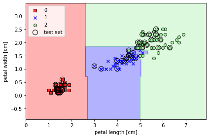

```python
from sklearn.ensemble import RandomForestClassifier
forest = RandomForestClassifier(criterion='gini', n_estimators=25, random_state=1, n_jobs=2)
forest.fit(X_train, y_train)
plot_decision_regions(X_combined, y_combined,
classifier=forest, test_idx=range(105,150))
plt.xlabel('petal length [cm]')
plt.ylabel('petal width [cm]')
plt.legend(loc='upper left')
plt.tight_layout()
plt.show()
```